# Camera-Media-Status

Anna Willoughby

# Status of Canyon Critters Camera Media

Report date: **2022-11-22**

## Camera Method Summary

Camera traps deployed at natural (outdoor) and building (indoor) sites in Grand Canyon and Zion National Parks capture animal activity by recording images or videos of detected movement. Camera data is collected seasonally, on average every 3 months. Collected data is organized and formatted for upload to Zooniverse, where citizen science volunteers help to identify animals recorded by the cameras.

Sites are the locations where cameras are deployed alongside a tunnel containing bait and hair and paw print collection materials. Sites are either natural sites located in outdoor locations in the parks, or building sites located in areas of park buildings such as crawlspaces and attics. Each site has a unique alphanumeric ID.

Camera check events are the events when sites are checked. Camera data is collected and fresh SD cards and batteries are installed. Camera checks are named for the date the data is collected, which is the final day of that check event. Camera checks are named with the site ID, “CC” for camera check, and the date of collection. Check event duration is measured in days.

Each camera check event contains some number of trigger events, the instances in which the camera was triggered to record photos or video. Trigger events are intended to capture animal activity, but in some instances movement due to wind, light, or other non-animal sources causes a camera to trigger. As such, animal detections are “successful” trigger events in which the camera was activated by animal movement, while trigger events may be animal detections or false triggers.

Study days are the dates during which cameras generally are collecting data. Camera days are the dates during which an individual camera is collecting data, and consist of a study day combined with a site ID.

## Study Design and Maintenance

From **2020-10-22**, cameras were deployed at **42** sites over **740** days, for a total of **25,553** camera days. **21** (**50%**) cameras are located at natural sites and **21** (**50%**) are located at building sites. The cameras were functional for **4,551** camera days, **17.8%** of the study period. Camera function was interrupted when a camera had a full SD card (**102** camera days [**0.4%**]), a dead battery (**296** camera days [**1%**]), or was dislodged or misplaced (**117** camera days [**0.5%**]).

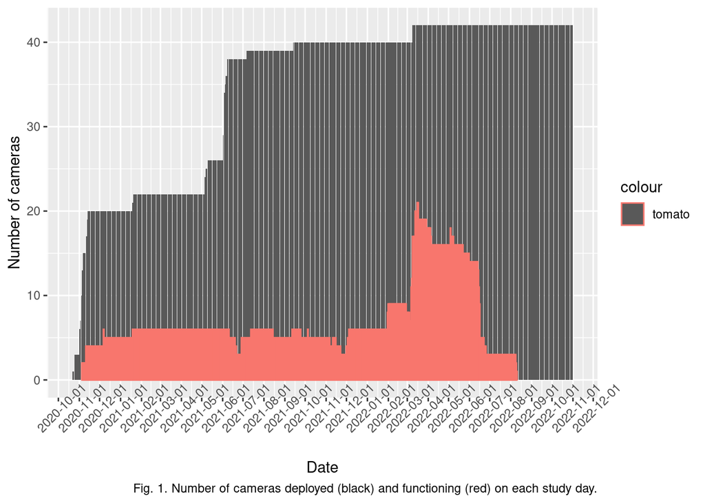

## Data Storage and Status

Camera data is stored by check event. Of the **339** check events, **243** (**71.7%**) are stored in two physical locations. **92** (**27.1%**) are uploaded to the Canyon Critters Zooniverse project.

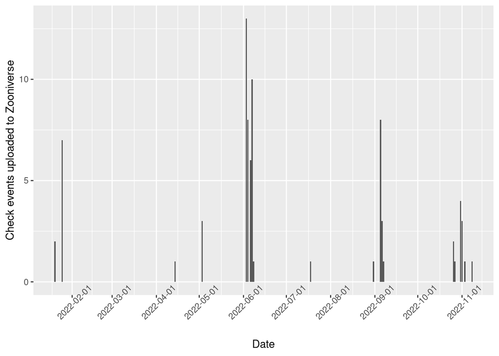